# Practical 3 - INLA-SPDE for geostatistical data

Spatial and Spatio-Temporal Bayesian Models with `R-INLA`

## 1. Introduction

In this practical we will make use of INLA-SPDE and `inlabru` for implementing a spatial model and performing spatial prediction. We will use a dataset related to **daily temperature measurements** automatically collected at 123 meteorological stations in Croatia on 19,th July 2006. Moreover, information about elevation (in mt) and distance in km from the coastline are available on a regular grid. The data are part of a bigger dataset available from http://book.spatial-analyst.net/HRtemp2006 and containing information for all days in 2006. In the following we will implement a spatial model with temperature as response variable and elevation and distance as covariates.

The data are included in the workspace `temperature.croatia.Rdata` which can be loaded in `R` via

```r
library(tidyverse)
library(INLA)
library(inlabru)
library(viridis) #for colors
# Remove old objects
remove(list=ls())
# Remember to set the correct working directory
load("temperature.croatia.Rdata")
ls()
```

```
## [1] "grid_cov"      "stations_data"
```

## 2. Explore and analyse the data

The workspace contains two `data.frame` objects:

1. The first is named `stations_data` and contains information about the 123 meteorological stations. Exploring the data

```r
glimpse(stations_data)
```

```
## Rows: 123
## Columns: 10
## $ IDT_AK <fct> GL001, GL002, GL003, GL004, GL005, GL006, GL007, GL008, GL009, …
## $ DATE   <fct> 2006-7-19, 2006-7-19, 2006-7-19, 2006-7-19, 2006-7-19, 2006-7-1…
## $ MDTEMP <dbl> 25.1, 24.2, 21.4, 24.9, 24.2, 20.9, 23.7, 24.8, 21.5, 26.6, 25.…
## $ cday   <int> 13347, 13347, 13347, 13347, 13347, 13347, 13347, 13347, 13347, …
## $ HRdem  <int> 161, 134, 202, 31, 205, 563, 80, 96, 116, 228, 291, 299, 23, 69…
## $ HRdsea <dbl> 198.5, 181.7, 192.9, 0.0, 1.5, 54.1, 230.9, 0.4, 128.2, 22.0, 0…
## $ Lat    <dbl> 45.88512, 45.91850, 45.59656, 42.65101, 42.56468, 44.54658, 45.…
## $ Lon    <dbl> 17.20566, 16.84590, 17.23278, 18.07596, 18.26662, 15.36686, 18.…
## $ UTMX   <dbl> 670760.2, 643072.6, 673777.8, 752343.8, 767729.1, 529629.6, 790…
## $ UTMY   <dbl> 5083464, 5086417, 5052001, 4726567, 4717878, 4933141, 5006251, …
```

we see that the it includes 10 variables. The important variables for the application are:

- elevation (`HRdem`)
- distance from the coastline (`HRdsea`)
- latitude (`Lat`)
- longitude (`Lon`)
2. The second data frame is named `grid_cov` and contains the same relevant information for a regular grid of 1250 points (25 $\times$ 50):

```r
glimpse(grid_cov)
```

```
## Rows: 1,250
## Columns: 4
## $ HRdem  <int> 1181, 1675, 628, 530, 368, 87, 0, 0, 0, 0, 0, 0, 0, 0, 0, 0, 0,…
## $ HRdsea <dbl> 209.0, 151.8, 45.4, 19.8, 14.6, 1.2, 0.0, 0.0, 0.0, 0.0, 0.0, 0…
## $ Lon    <dbl> 13.17595, 13.44143, 13.70691, 13.97238, 14.23786, 14.50333, 14.…
## $ Lat    <dbl> 42.10123, 42.10123, 42.10123, 42.10123, 42.10123, 42.10123, 42.…
```

The regular grid (gray points) together with the monitor stations (red points) are represented in the following plot:

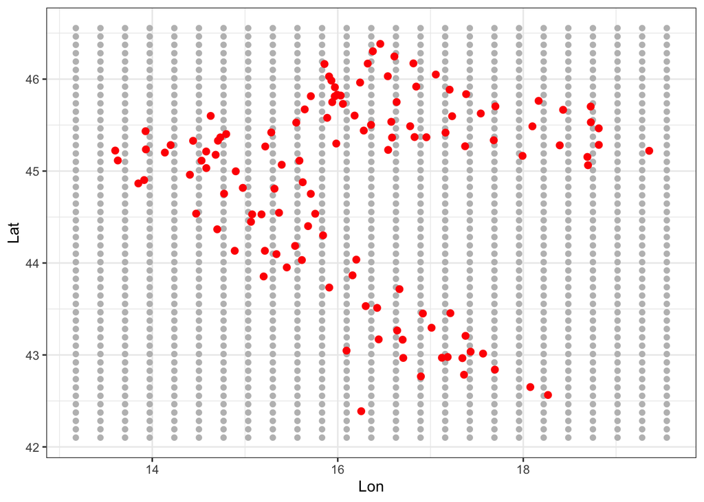

```r
ggplot()+
  geom_point(data = grid_cov, aes(Lon,Lat),
             col = "gray") +
  geom_point(data = stations_data, aes(Lon,Lat),
             col = "red", size = 2) +
  theme_bw()
```

We plot also the distribution of the response variable `MDTEMP` (histogram + density function):

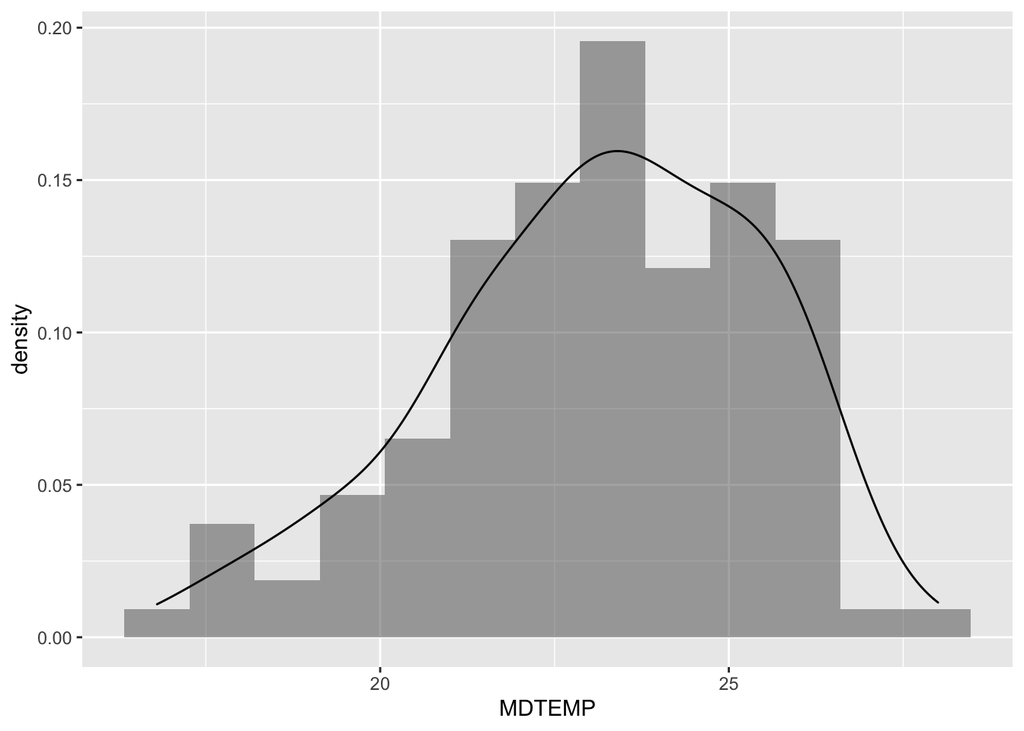

```r
stations_data %>%
  ggplot() +
  geom_histogram(aes(MDTEMP, after_stat(density)),bins = 13, alpha=0.5) +
  geom_density(aes(MDTEMP))
```

```r
shapiro.test(stations_data$MDTEMP)
```

```
##
##  Shapiro-Wilk normality test
##
## data:  stations_data$MDTEMP
## W = 0.97674, p-value = 0.04262
```

It can also be useful to plot the values of the covariate `HRdem` (elevation) for both the monitoring station sites and the points of the regular grid. To do this we will use the quantiles of the distributions to create a `factor` variable.

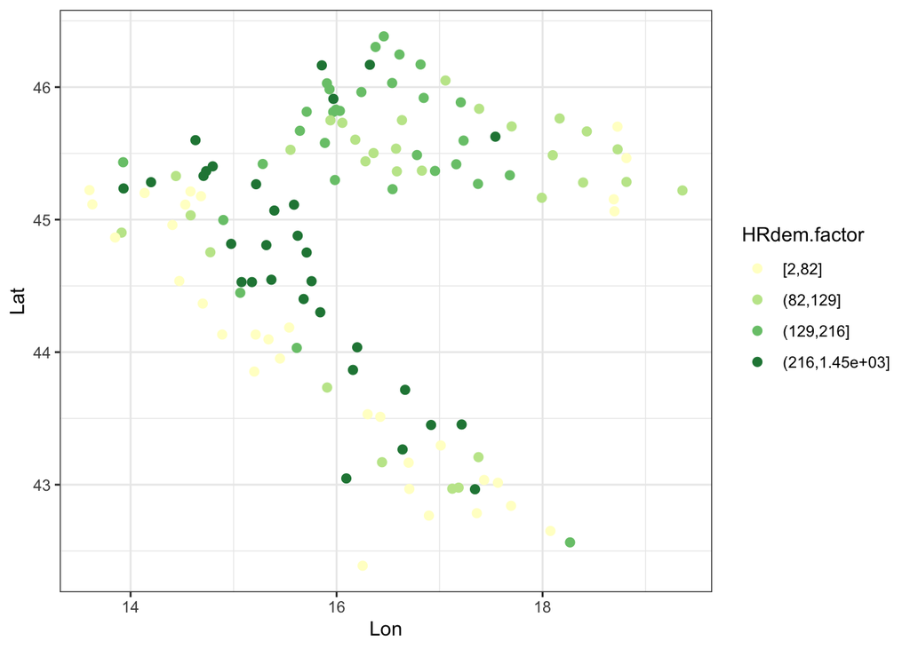

```r
#HRdem monitoring stations
stations_data %>%
  mutate(HRdem.factor = cut(HRdem,
                    breaks = quantile(HRdem),
                    include.lowest = TRUE,
                    right = TRUE)) %>%
  ggplot() +
  geom_point(aes(Lon, Lat, col = HRdem.factor), size = 2) +
  scale_color_brewer(palette = "YlGn") +
  theme_bw()
```

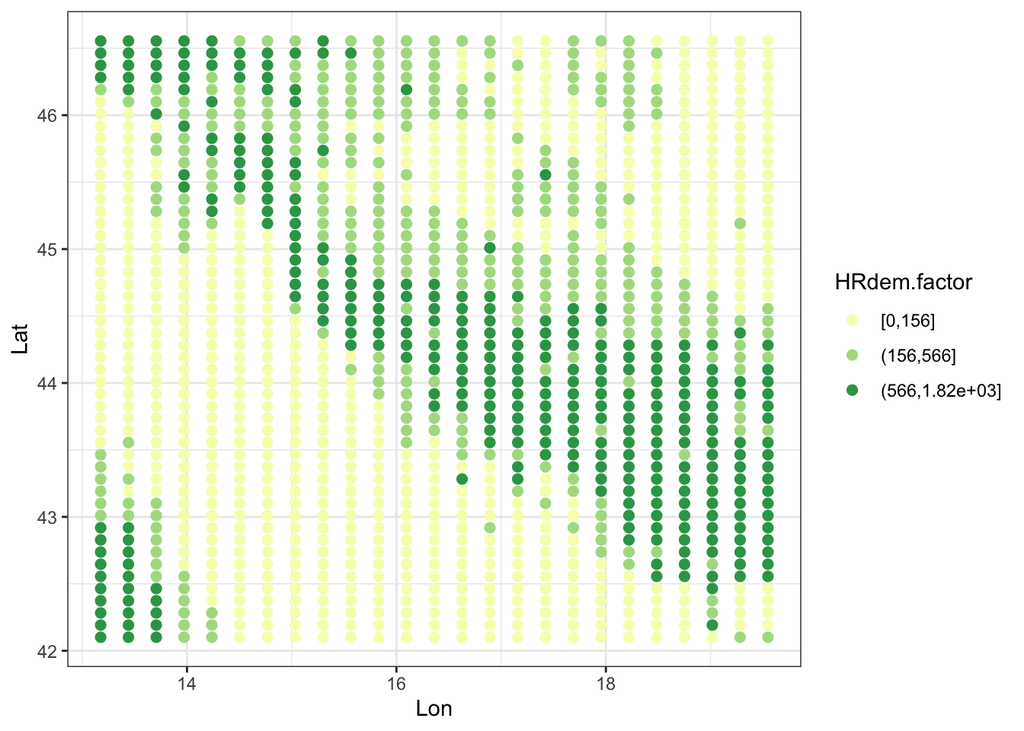

```r
#HRdem grid points
grid_cov %>%
  mutate(HRdem.factor = cut(HRdem,
                    breaks = unique(quantile(HRdem)), #the first and the second quantiles are equal
                    include.lowest = TRUE,
                    right = TRUE)) %>%
  ggplot() +
  geom_point(aes(Lon, Lat, col = HRdem.factor), size = 2) +
  scale_color_brewer(palette = "YlGn") +
  theme_bw()
```

## 3. Model

We assume the following spatial model
$$y_i \sim \text{Normal}(\eta_i, \sigma^2_e) \qquad i=1,\ldots, 123$$
where $\sigma^{2}_e$ is the variance of the zero mean measurement error $e_i$ which is supposed to be normally distributed and independent on $e_{j}$ for each $i\neq j$ and the linear predictor given by
$$\eta_i = \beta_0+ \beta_1 \texttt{HRdem}_i + \xi_i$$
including an intercept $\beta_0$, a linear effect $\beta_1$ of elevation and the spatial random effect $\xi_i$ which is a priori a Matern GF.

## 4. Mesh construction

The first step for implementing the SPDE approach is the definition of the mesh. Since in this case the Croatia borders are quite irregular we use the new `inla.nonconvex.hull` function:

```r
bnd = inla.nonconvex.hull(cbind(stations_data$Lon,stations_data$Lat),
                          convex=0.25)

croatia.mesh = inla.mesh.2d(loc = cbind(stations_data$Lon,
                                       stations_data$Lat),
                          boundary = bnd,
                          offset = c(1, 2),
                          max.edge = c(3, 8),
                          cutoff = 0.3)
```

The mesh plot can be obtained using standard code

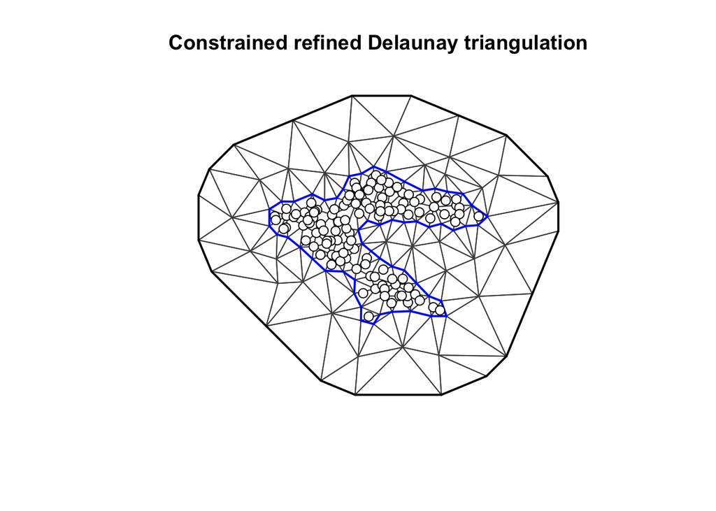

```r
plot(croatia.mesh,asp=1)
points(stations_data$Lon, stations_data$Lat, pch=21, cex=1.2, bg="white",col=1)
```

or using the `inlabru` package function `gg` (using `ggplot` style)

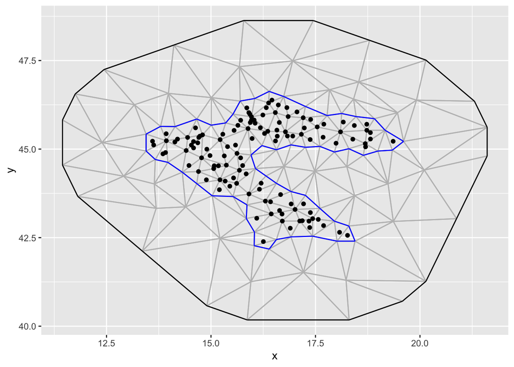

```r
ggplot() +
  gg(croatia.mesh) +
  geom_point(data = stations_data, aes(Lon, Lat))
```

## 5. Model fitting with `inla.stack`

We use `R-INLA` and the `inla.stack` funtion to estimate the parameters of the given model where $\{\bm \xi,\beta_0,\beta_1\}$ and the hyperparameter vector contains $\sigma^2_e$, the spatial variance $\sigma^2$ and the spatial range $r$.

1. We start by creating the SPDE model object

```r
spde = inla.spde2.matern(mesh = croatia.mesh)
```

The number of vertices of the mesh can be retrieved with

```r
spde$n.spde
```

```
## [1] 133
```

2. We define the projector matrix $\bm A$ and the `inla.stack` object for the **estimation** part:

```r
A.est = inla.spde.make.A(croatia.mesh,
                         loc = as.matrix(cbind(stations_data$Lon,stations_data$Lat)))
dim(A.est)
```

```
## [1] 123 133
```

```r
stack.est = inla.stack(data = list(temp = stations_data$MDTEMP),
                       A = list(A.est, 1, 1),
                       effects = list(spatial.index = 1:spde$n.spde,
                                      Intercept = rep(1, nrow(stations_data)),
                                      HRdem = stations_data$HRdem),
                       tag="est")
```

3. We define now the projector matrix $\bm A$ and the `inla.stack` object for the **prediction** part considering the `grid_cov` regular grid:

```r
A.pred = inla.spde.make.A(croatia.mesh,
                          loc = cbind(grid_cov$Lon,grid_cov$Lat))
dim(A.pred)
```

```
## [1] 1250  133
```

```r
stack.pred = inla.stack(data = list(temp = NA),
                        A = list(A.pred, 1, 1),
                        effects = list(spatial.index = 1:spde$n.spde,
                                       Intercept = rep(1, nrow(grid_cov)),
                                       HRdem = grid_cov$HRdem),
                        tag = "pred")
```

4. Finally we join all the `inla.stack` objects, define the `formula` and run the `inla` function (including also the computation of DIC):

```r
fullstack = inla.stack(stack.est, stack.pred)

formula = temp ~ -1 + Intercept + HRdem + f(spatial.index, model = spde)

output = inla(formula,
       data = inla.stack.data(fullstack, spde = spde),
       family = "gaussian",
       control.predictor = list(A = inla.stack.A(fullstack), compute = TRUE),
       control.compute = list(dic = TRUE))
```

We extract now the posterior distribution of the **fixed effects** as follows

```r
output$summary.fixed
```

```
##                   mean           sd   0.025quant     0.5quant   0.975quant
## Intercept 24.450045026 0.7574436946 22.858665523 24.459070917 25.982194844
## HRdem     -0.005646563 0.0005896663 -0.006805628 -0.005646382 -0.004488555
##                   mode          kld
## Intercept 24.469683924 4.798533e-06
## HRdem     -0.005646048 1.877079e-09
```

and we note the significative and negative effect of elevation (even if small). It is also possible to plot the marginal posterior of intercept and elevation:

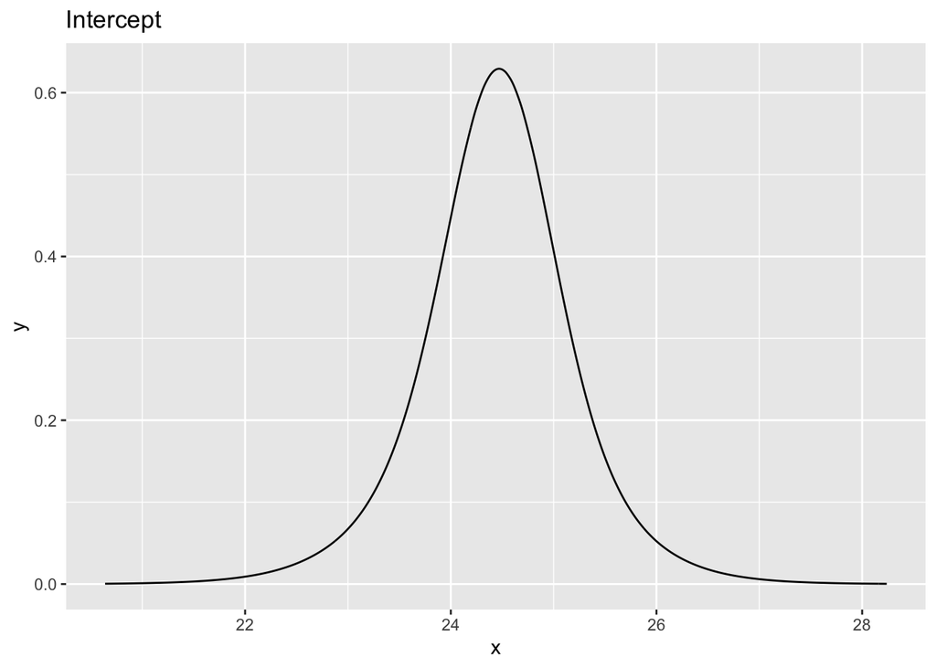

```r
inla.smarginal(output$marginals.fixed$Intercept) %>%
  dplyr::bind_rows() %>%  #from list to data frame
  ggplot() +
  geom_line(aes(x,y)) +
  ggtitle("Intercept")
```

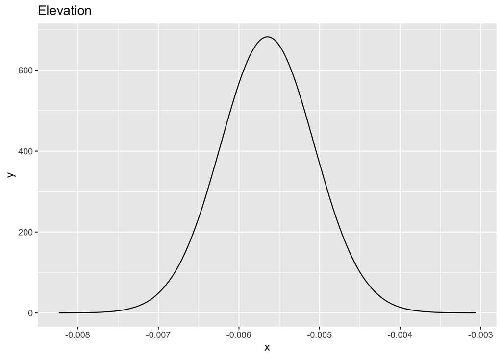

```r
inla.smarginal(output$marginals.fixed$HRdem) %>%
  dplyr::bind_rows() %>%  #from list to data frame
  ggplot() +
  geom_line(aes(x,y)) +
  ggtitle("Elevation")
```

Then we compute the posterior summaries (mean, standard deviation and 0.025, 0.5, 0.975 quantiles) about the Gaussian observation variance $\sigma^2_e$ by transforming the precision posterior distribution with `inla.tmarginal`:

```r
sigma2e_marg =
  inla.tmarginal(function(x) 1/x,
  output$marginals.hyperpar$"Precision for the Gaussian observations")

inla.zmarginal(sigma2e_marg)
```

```
## Mean            1.29128
## Stdev           0.211726
## Quantile  0.025 0.931785
## Quantile  0.25  1.14029
## Quantile  0.5   1.27095
## Quantile  0.75  1.42072
## Quantile  0.975 1.76142
```

The posterior summaries of the spatial parameters can be extracted from the output by means of the `inla.spde2.result` function:

```r
output.field = inla.spde2.result(inla = output,
                                 name = "spatial.index",
                                 spde = spde,
                                 do.transf = TRUE)
```

Then we use the following code to retrieve the piece of information we need for the spatial variance and the range:

```r
var.nom.marg = output.field$marginals.variance.nominal[[1]]
inla.zmarginal(var.nom.marg)
```

```
## Mean            2.61623
## Stdev           1.13535
## Quantile  0.025 1.07665
## Quantile  0.25  1.80865
## Quantile  0.5   2.38703
## Quantile  0.75  3.16872
## Quantile  0.975 5.46379
```

```r
range.nom.marg = output.field$marginals.range.nominal[[1]]
inla.zmarginal(range.nom.marg)
```

```
## Mean            1.92899
## Stdev           0.683976
## Quantile  0.025 0.957934
## Quantile  0.25  1.44039
## Quantile  0.5   1.80176
## Quantile  0.75  2.27937
## Quantile  0.975 3.61352
```

When interpreting the posterior mean of the range, consider that the maximum distance between station sites is 5.75.

Finally we extract the DIC through

```r
output$dic$dic
```

```
## [1] 386.6315
```

This information will be used later for model comparison.

## 6. Model fitting with `inlabru`

We first transform the `stations_data` `data.frame` into a `SpatialPointsDataFrame`:

```r
coordinates(stations_data) = c("Lon","Lat")
class(stations_data)
```

```
## [1] "SpatialPointsDataFrame"
## attr(,"package")
## [1] "sp"
```

We then define the model components

```r
cmp1 = MDTEMP ~ Intercept(1) + HRdem + s.field(main = coordinates, model = spde)
```

and the likelihood:

```r
lik1 = like(formula = MDTEMP ~ Intercept + HRdem + s.field,
             family = "gaussian",
             data = stations_data)
```

And finally run the `bru` function:

```r
outputbru <- bru(cmp1, lik1)
```

And now let’s compare the output for the fixed effects and the hyperparameters from the two approaches:

```r
output$summary.fixed
```

```
##                   mean           sd   0.025quant     0.5quant   0.975quant
## Intercept 24.450045026 0.7574436946 22.858665523 24.459070917 25.982194844
## HRdem     -0.005646563 0.0005896663 -0.006805628 -0.005646382 -0.004488555
##                   mode          kld
## Intercept 24.469683924 4.798533e-06
## HRdem     -0.005646048 1.877079e-09
```

```r
outputbru$summary.fixed
```

```
##                   mean          sd   0.025quant     0.5quant   0.975quant
## Intercept 24.450368731 0.759161591 22.850729603 24.459723476 25.988796681
## HRdem     -0.005646597 0.001160987 -0.007923826 -0.005646565 -0.003369547
##                   mode          kld
## Intercept 24.470534552 8.115718e-06
## HRdem     -0.005646502 1.463696e-11
```

```r
output$summary.hyperpar
```

```
##                                               mean        sd 0.025quant
## Precision for the Gaussian observations  0.7951252 0.1298394  0.5657193
## Theta1 for spatial.index                -2.1383567 0.3083111 -2.7275921
## Theta2 for spatial.index                 0.4404590 0.3402111 -0.2547547
##                                           0.5quant 0.975quant       mode
## Precision for the Gaussian observations  0.7863572   1.076328  0.7711691
## Theta1 for spatial.index                -2.1455152  -1.509165 -2.1741224
## Theta2 for spatial.index                 0.4486686   1.089815  0.4815496
```

```r
outputbru$summary.hyperpar
```

```
##                                               mean        sd 0.025quant
## Precision for the Gaussian observations  0.7878985 0.1271060  0.5660395
## Theta1 for s.field                      -2.1164931 0.2971544 -2.6959406
## Theta2 for s.field                       0.4159037 0.3384320 -0.2622246
##                                           0.5quant 0.975quant       mode
## Precision for the Gaussian observations  0.7782482   1.065925  0.7598161
## Theta1 for s.field                      -2.1191853  -1.522164 -2.1295813
## Theta2 for s.field                       0.4194069   1.074616  0.4329789
```

## 7. Mapping spatial prediction with `inla.stack`

We will now use the linear predictor posterior mean to create a map of the temperature field for the regular grid covering Croatia. To access the posterior marginal distributions of predictions at the target grid locations, we extract with the `inla.stack.index` function the corresponding data indexes from the full stack object using the corresponding tags:

```r
index.pred = inla.stack.index(stack = fullstack, "pred")$data
```

Then we save the posterior mean and sd with

```r
post.mean.pred = output$summary.linear.predictor[index.pred, "mean"]
post.mean.sd = output$summary.linear.predictor[index.pred, "sd"]
```

and reshape these objects as matrix with the grid dimension (25 $\times$ 50):

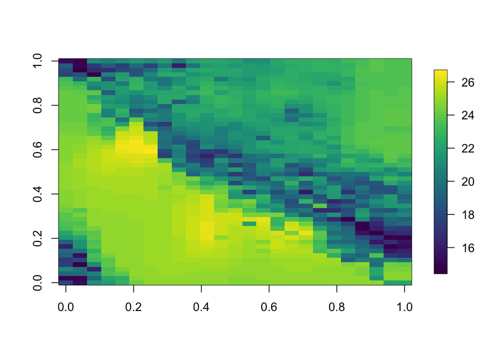

```r
library(fields)


image.plot(matrix(post.mean.pred, 25, 50), col = viridis(64))
```

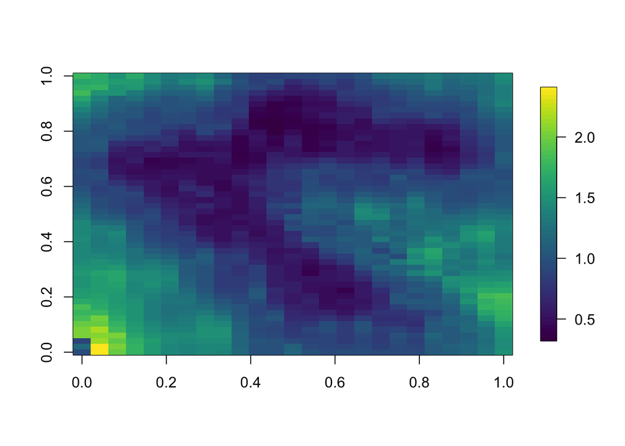

```r
image.plot(matrix(post.mean.sd, 25, 50), col = viridis(64))
```

## 8. Mapping spatial prediction with `inlabru`

We transform first of all the `grid_cov` `data.frame` object into a `SpatialPixelsDataFrame`:

```r
coordinates(grid_cov) = c("Lon", "Lat")
gridded(grid_cov) = TRUE
class(grid_cov)
```

```
## [1] "SpatialPixelsDataFrame"
## attr(,"package")
## [1] "sp"
```

```r
pred = predict(outputbru, grid_cov,
              ~ Intercept + HRdem + s.field,
              seed = 1)
head(pred)
```

```
## Object of class SpatialPixelsDataFrame
## Object of class SpatialPixels
## Grid topology:
##     cellcentre.offset   cellsize cells.dim
## Lon          13.17595 0.26547599        25
## Lat          42.10123 0.09088111        50
## SpatialPoints:
##           Lon      Lat
## [1,] 13.17595 42.10123
## [2,] 13.44143 42.10123
## [3,] 13.70691 42.10123
## [4,] 13.97238 42.10123
## [5,] 14.23786 42.10123
## [6,] 14.50333 42.10123
## Coordinate Reference System (CRS) arguments: NA
##
## Data summary:
##      HRdem            HRdsea            mean             sd
##  Min.   :  87.0   Min.   :  1.20   Min.   :14.98   Min.   :1.299
##  1st Qu.: 408.5   1st Qu.: 15.90   1st Qu.:18.51   1st Qu.:1.493
##  Median : 579.0   Median : 32.60   Median :21.33   Median :1.667
##  Mean   : 744.8   Mean   : 73.63   Mean   :20.38   Mean   :1.782
##  3rd Qu.:1042.8   3rd Qu.:125.20   3rd Qu.:22.40   3rd Qu.:1.830
##  Max.   :1675.0   Max.   :209.00   Max.   :24.33   Max.   :2.742
##      q0.025           median          q0.975           smin
##  Min.   : 9.704   Min.   :15.20   Min.   :19.72   Min.   : 8.613
##  1st Qu.:15.058   1st Qu.:18.60   1st Qu.:21.16   1st Qu.:13.898
##  Median :17.781   Median :21.45   Median :24.26   Median :16.786
##  Mean   :16.806   Mean   :20.49   Mean   :23.30   Mean   :16.028
##  3rd Qu.:19.243   3rd Qu.:22.45   3rd Qu.:24.83   3rd Qu.:18.878
##  Max.   :21.688   Max.   :24.42   Max.   :26.38   Max.   :21.470
##       smax             cv               var
##  Min.   :20.89   Min.   :0.05336   Min.   :1.686
##  1st Qu.:21.95   1st Qu.:0.06676   1st Qu.:2.238
##  Median :24.54   Median :0.08277   Median :2.779
##  Mean   :23.87   Mean   :0.09349   Mean   :3.395
##  3rd Qu.:25.08   3rd Qu.:0.09389   3rd Qu.:3.355
##  Max.   :26.90   Max.   :0.18304   Max.   :7.521
```

We plot here below the posterior mean and standard deviation of the linear predictor:

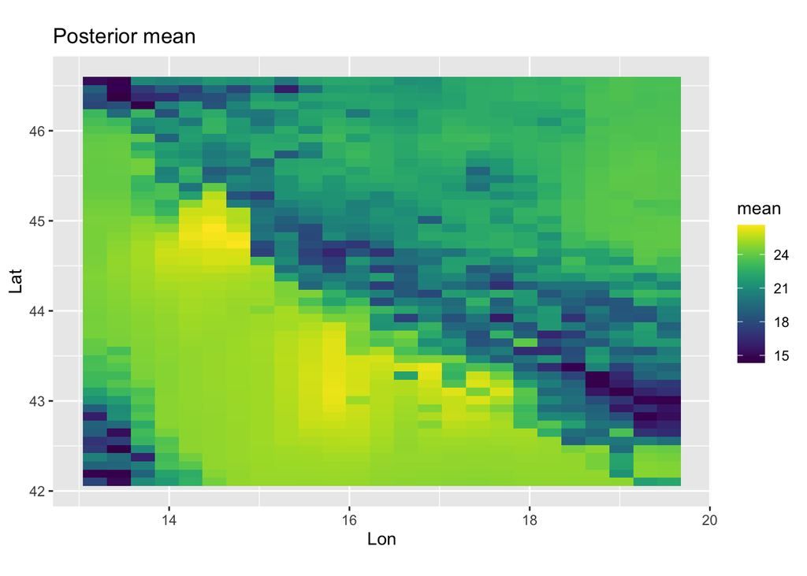

```r
ggplot() +
  gg(pred, aes(Lon, Lat, fill = mean)) +
  ggtitle("Posterior mean") +
  coord_fixed() +
  scale_fill_viridis()
```

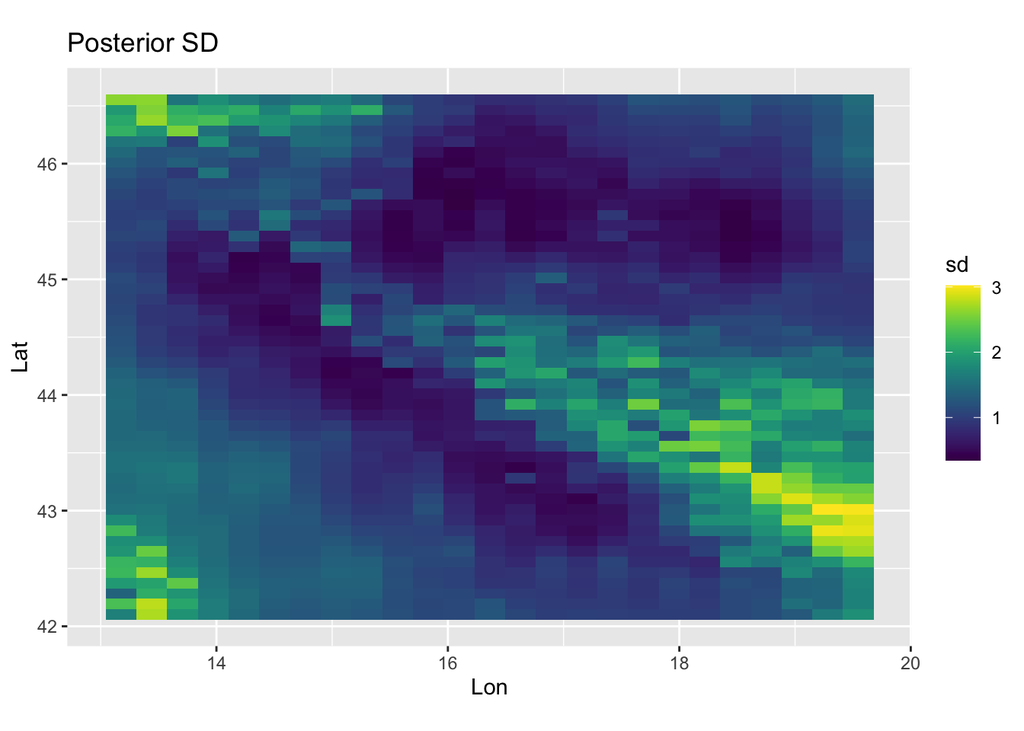

```r
ggplot() +
  gg(pred, aes(Lon, Lat, fill = sd)) +
  ggtitle("Posterior SD") +
  coord_fixed() +
  scale_fill_viridis()
```

## 9. Model comparison

We want now to implement a new spatial model including in the fixed effects also the covariate `HRdsea` (distance from the see). We will then compare the two model with the DIC index. The following code (not commented) implemented the second model using `inlabru`:

```r
cmp2 = MDTEMP ~ 1 + HRdem + HRdsea + s.field(main = coordinates, model = spde)
lik2 = like(formula = MDTEMP ~ Intercept + HRdem + HRdsea + s.field,
             family = "gaussian",
             data = stations_data)
outputbru2 = bru(cmp2, lik2)
```

Comparing the DIC values

```r
outputbru$dic$dic
```

```
## [1] 386.2635
```

```r
outputbru2$dic$dic
```

```
## [1] 381.1478
```